# PATH analysis of idealized phylogenies

```r
library(PATH)
library(expm)
library(ggplot2)
library(ggtree)
library(ggtreeExtra)
library(tidytree)
library(Matrix)
library(patchwork)

options(digits = 2)
```

### Introduction

In this vignette we demonstrate how to use PATH to measure categorical cell state phylogenetic correlations and how to infer cell state transition dynamics on phylogenies from simulations of *idealized* phylogenies. For a similar analysis using phylogenies simulated as a *sampled somatic evolutionary process*, see this vignette. For more information about PATH, see our bioRxiv preprint.

In the first section, a mathematical (Markov) model of cell state transition dynamics is introduced.

In the second section, we apply PATH to analyze cell state patterns on an idealized phylogeny.

### Cell state transition dynamics as a Markov process

In this vignette we model the transitions between cell states over the course of somatic evolution as a [Markov process](https://en.wikipedia.org/wiki/Markov_chain). This means that transitions between cell states occur stochastically, *i.e.*, with some probability, and that the probability that a cell transitions to any state only depends on its current state.

In order to simulate cell state transition dynamics during somatic evolution we need to specify the $n$ number of possible distinct cell states and the $n^2$ transition probabilities connecting these states with the transition probability matrix $\mathbf{P}$. Each element $P_{ij}$ of this square $n$-dimensional matrix represents the probability of transitioning *from* state $i$ *to* state $j$, after one unit of time.

This matrix can be user-defined, for example, as shown below, but note that each row of $\mathbf{P}$ must sum to $1$.

```r
# Example of a user-defined 2-dimensional transition probability matrix:
P <- matrix(c(0.90, 0.08, 0.02,
              0.10, 0.80, 0.10,
              0.02, 0.08, 0.90),
            3, 3,
            byrow = T)
P
```

```
#>      [,1] [,2] [,3]
#> [1,] 0.90 0.08 0.02
#> [2,] 0.10 0.80 0.10
#> [3,] 0.02 0.08 0.90
```

```r
# The probability of transitioning
# from state 1 to state 2
# after one time-step is:
P[1,2]
```

```
#> [1] 0.08
```

```r
# Likewise, the probability for a cell in state 1
# to remain in state 1 (i.e., not transition to any other state)
# after one time-step is:
P[1,1]
```

```
#> [1] 0.9
```

For a *discrete-time* model, the probabilities of transitioning between states after $t$ units of time (where $t$ is an integer), is given by $\mathbf{P}^t$.

```r
# Transition probabilities between cell states after 3 time-steps,
# where '%^%' denotes the matrix power, is

P%^%3
```

```
#>      [,1] [,2] [,3]
#> [1,] 0.75 0.18 0.07
#> [2,] 0.22 0.55 0.22
#> [3,] 0.07 0.18 0.75
```

Furthermore, for very large $t$, transition probabilities converge to a *stationary* distribution, which in some cases, can be understood as the cell state equilibrium frequencies.

For example, the rows of $\mathbf{P}^{1000}$ should converge to the stationary distribution (computed using the [Perron Frobenius theorem](https://en.wikipedia.org/wiki/Perron%E2%80%93Frobenius_theorem)),

```r
# Transition probability matrix after 1,000 time-steps
P%^%1000
```

```
#>      [,1] [,2] [,3]
#> [1,] 0.36 0.29 0.36
#> [2,] 0.36 0.29 0.36
#> [3,] 0.36 0.29 0.36
```

```r
# Stationary distribution of P
CGE::PF_eig(t(P))$vec
```

```
#> [1] 0.36 0.29 0.36
```

In the next section we use PATH to analyze “idealized” phylogenies in which cell state transitions occur over discrete time-steps, as generations are non-overlapping and of equal duration, and so can be modeled using discrete-time transitions. However, for the sampled somatic evolutionary process model, time is measured in continuous, not discrete, units, as generations can overlap, and the time between sequential cell divisions is not constant.

The transition *probability* matrix $\mathbf{P}$ can be transformed into a transition *rate* matrix $\mathbf{Q}$ by taking the matrix logarithm, that is, $\mathbf{Q} = \log \mathbf{P}$. The elements in each row of $\mathbf{Q}$ must sum to $0$, with the diagonal element equal to the negative sum of the off-diagonal elements (which are each $\geq 0$), *i.e.*, $Q_{ii} = -\sum_{j \neq i} Q_{ij}$.

To compute the transition probabilities $\mathbf{P}(t)$ for a (continuous) time-step $t$, we take the [matrix exponential](https://en.wikipedia.org/wiki/Matrix_exponential) of $\mathbf{Q}$, such that $\mathbf{P}(t)=e^{\mathbf{Q}t}$.

```r
# Get Q, the transition rate matrix by taking the matrix logarithm of P.
Q <- expm::logm(P)

Q
```

```
#>        [,1]   [,2]   [,3]
#> [1,] -0.111  0.094  0.017
#> [2,]  0.117 -0.235  0.117
#> [3,]  0.017  0.094 -0.111
```

### Idealized phylogenies

In this section we simulate cell state transition dynamics (modeled as a Markov process discussed above) on an idealized phylogeny. An *idealized phylogeny* – is the term we use to refer to a completely sampled, discrete-time, balanced, and bifurcating trees. Idealized phylogenies are a useful setting to understand how PATH works.

#### Simulate

First, we simulate an idealized phylogeny containing $N = 2^g$ cells with the fuction `idealized_phylogeny(g, Q)`. The first argument determines the number of cellular generations since all cells shared the same ancestor, and the second argument specifies the transition rate matrix. Below, we set `g = 9`, resulting in a phylogeny with $512$ leaves, and use the transition rate matrix defined above.

```r
# Simulate idealized phylogeny (phy0).
# Where g is the number of generations back to the root,
# and Q is the transition rate matrix (Q).
Q
```

```
#>        [,1]   [,2]   [,3]
#> [1,] -0.111  0.094  0.017
#> [2,]  0.117 -0.235  0.117
#> [3,]  0.017  0.094 -0.111
```

```r
phy0 <- idealized_phylogeny(g = 9, Q = Q)
```

Below, we plot the phylogeny and annotate the state of each cell. Some cell states can appear clustered or co-clustered on the phylogeny, but we need to measure phylogenetic correlations to quantify these patterns, and assess their statistical significance.

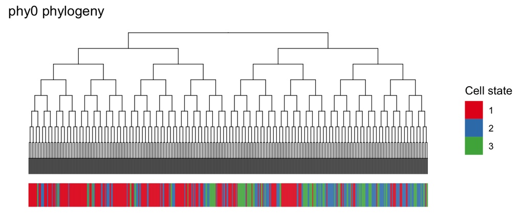

#### Measure phylogenetic correlations

To measure phylogenetic correlations, we use the function `xcor(X, W)`.

`W` is a phylogenetic weight matrix, and below we compute it with the function `one_node_tree_dist()`, which only gives weight to phylogenetic relationships where cells are separated by a node distance of $1$ – that is, only sister cell pairs – on idealized phylogenies, and assigns a weight of $0$ to all other phylogenetic relationships.

Next we use the function `catMat()` to transform the cell state vector `phy0$states` into the matrix `X` (note this function is only intended for formatting “categorical” cell states, *i.e.*, when a cell can only be in one possible state at a time)).

```r
# Get phylogenetic node distance matrix
# retaining only node distances of 1.
W <- one_node_tree_dist(phy0)


# Cell states are stored in the vector phy0$states. The first 10 states are:
phy0$states[1:10]
```

```
#>  [1] 1 1 1 1 1 1 1 1 1 1
```

```r
# Transform vector of cell state assignments into matrix
# format for calculating phylogenetic correlations.
X <- catMat(phy0$states)

# Compute phylogenetic correlations with xcor().
# Output of xcor() is a list,  including:
# phylogenetic correlations ("Morans.I"), and
# leaf-permutation based
# analytical z scores ("Z.score"),
# variance ("Var.I"), expected values ("Expected.I"),
# and one-sided p-values ("one.sided.pvalue").
phy0xcor <- xcor(X, W)

# Phylogenetic correlations
phy0xcor$phy_cor
```

```
#>       1     2     3
#> 1  0.66 -0.35 -0.41
#> 2 -0.35  0.50 -0.15
#> 3 -0.41 -0.15  0.68
```

```r
# Phylogenetic correlation z scores
phy0xcor$Z.score
```

```
#>      1    2    3
#> 1 10.5 -6.7 -8.3
#> 2 -6.7  8.0 -3.2
#> 3 -8.3 -3.2 11.0
```

We use phylogenetic auto-correlations as a measure of cell state clustering, or heritability, and the concordant z scores to assess statistical significance. Both auto-correlations `diag(phy0xcor$phy_cor)` and z scores `diag(phy0xcor$Z.scores)` are plotted below.

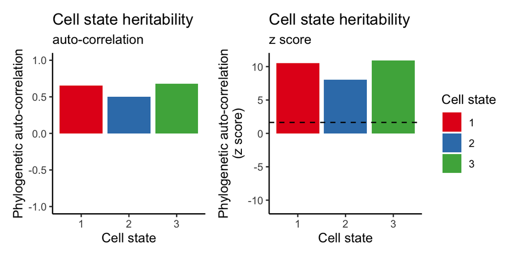

The phylogenetic relationships between cell states as quantified with phylogenetic cross-correlations `phy0xcor$phy_cor` can be visualized as a heat map, as below. Note that the diagonal of the heat map represents the same values as depicted in the auto-correlation bar plot above.

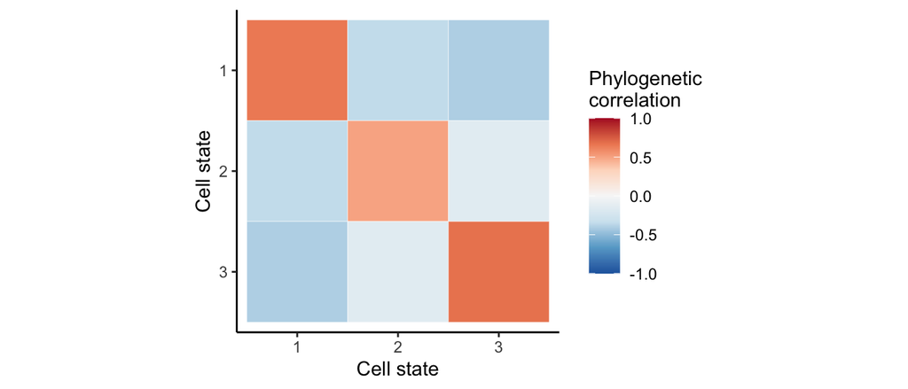

#### Infer cell state dynamics

Finally, we can use these phylogenetic correlations to infer cell state state transition dynamics with the function `PATH_inf()`. This function takes a phylogeny (here, `phy0`), the name of the cell state vector (here, `"states"` as cell states are stored at `phy0$states`), and `nstates`, the number of possible cell states.

```r
# Infer cell state transition probabilities from phylogenetic
# correlations and measured branch lengths using PATH.
Pinf <- PATH_inf(tree = phy0, cell_states = "states", nstates = nrow(P))
```

First we can see what the inferred transition probabilities are for a length of time proportional to the branch length distances separating sister cells, which is $t=2$, here.

```r
# PATH-inference of P(t=2)
Pinf$Pt
```

```
#>       1    2     3
#> 1 0.820 0.15 0.029
#> 2 0.223 0.66 0.114
#> 3 0.069 0.19 0.745
```

PATH uses the above transition probability to estimate $\mathbf{P}$ for a time-step of $t=1$.

We can compare inferred transitions to the true simulated transitions, for $t=1$.

```r
# PATH-inferred transitions
Pinf$P
```

```
#>       1     2     3
#> 1 0.899 0.088 0.013
#> 2 0.130 0.802 0.068
#> 3 0.031 0.111 0.859
```

```r
# True transitions
P
```

```
#>      [,1] [,2] [,3]
#> [1,] 0.90 0.08 0.02
#> [2,] 0.10 0.80 0.10
#> [3,] 0.02 0.08 0.90
```